# Intro to Data Science (Non-Technical Background, R) - Session22

Goran S. Milovanović, PhD

DataKolektiv, Chief Scientist & Owner; Data Scientist for Wikidata, WMDE

# Session 22. Regularization (L1 and L2) in regression problems. Running R code in parallel for efficient data processing and modeling.

**Feedback** should be send to `goran.milovanovic@datakolektiv.com`. These notebooks accompany the Intro to Data Science: Non-Technical Background course 2020/21.

### What do we want to do today?

In this session we will introduce an additional, important method to control for overfitting in regression models: **regularization**. Both *L1 (Lasso Regression)* and *L2 (Ridge Regression)* norms will be discussed and [{glmnet}](https://cran.r-project.org/web/packages/glmnet/index.html) R package will be used to fit regularized linear models. This session wraps-up our journey in the field of statistical machine learning in the scope of this course. In the second part of the session we will learn how to run R code in parallel w. [{snowfall}](https://cran.r-project.org/web/packages/snowfall/index.html). Then we dive into the first out of three case studies and begin a synthesis of everything that we have learned thus far.

### 0. Setup

```r
install.packages('glmnet')
install.packages('snowfall')
```

Grab the `HR_comma_sep.csv` dataset from the [Kaggle](https://www.kaggle.com/liujiaqi/hr-comma-sepcsv) and place it in your `_data` directory for this session. We will also use the [Boston Housing Dataset: BostonHousing.csv](https://raw.githubusercontent.com/selva86/datasets/master/BostonHousing.csv)

```r
dataDir <- paste0(getwd(), "/_data/")
library(tidyverse)
library(data.table)
library(glmnet)
```

### 1. Regularization in Linear Regression

#### 1.1 Lasso (L1), Ridge (L2), and Elastic Net regression

Regularization is used for several purposes:

- it helps reduce the problem of multicollinearity in Linear Regression,
- it is used as method of **feature selection** in large models, and
- it is used as a method to prevent overfitting.

Consider the following:

$$Loss = \sum_{i=1}^{n}{\big(y_i-\hat{y_i}\big)^2}$$

It is just the ordinary sum of squares, or the **loss** (or **cost**) function of the Linear Regression Model. The parameters $\beta$ of the Linear Model are estimate by minimizing the above quantity - the model’s *cost function*.

Now, consider the following formulation of the cost function that includes the *penalty term*:

$$Loss_{L2} = \sum_{i=1}^{n}{\big(y_i-\hat{y_i}\big)^2}+\lambda\sum_{j=1}^{p}\beta_j^2$$

$\lambda\sum_{j=1}^{p}\beta_j^2$ is the *penalty term*: it increases the value of the cost function by a factor determined by the sum of the squared model coefficients. In the expression above $p$ stands for the number of model parameters (coefficients, in the case of Linear Regression) and $\beta$ are the coefficients themselves. The above expression represents the $L2$ regularization for the Linear Model, also known as **Ridge Regression**. If $\lambda$ is zero we get back to the Ordinary Least Squares model that we have already learned about. If $\lambda$ is too large, it will add too much weight to the cost function which will lead to *underfitting*. The underlying idea is to *penalize* large coefficients: it *regularizes* the coefficients so that if they take large values the cost function is penalized. In effect, the Ridge regression shrinks the coefficients so to reduce the model complexity and reduces the effects multicollinearity.

Consider now the following modification of the cost function:

$$Loss_{L1} = \sum_{i=1}^{n}{\big(y_i-\hat{y_i}\big)^2}+\lambda\sum_{j=1}^{p}|\beta_j|$$

The above cost function is based on a weighted sum of the *absolute* values of the model coefficients. This approach is known as $L1$ or **Lasso Regression**.

The most important **difference between Ridge and Lasso regularization** is that in Lasso some coefficients can be *shrinked to zero* and get completely eliminated from the model. Thus, Lasso regularization does not only prevent overfitting but also performs **feature selection** - a very handy thing when considering large linear models.

Finally, consider the following formulation of a loss (or cost) function:

$$Loss_{ElasticNet} = \frac{\sum_{i=1}^{n}(y_i-\hat{y_i})^2}{2n}+\lambda(\frac{1-\alpha}{2}\sum_{j=1}^{m}\hat{\beta_j}^2+\alpha\sum_{j=1}^{m}|\hat{\beta_j}|)$$

In the expression above - the **Elastic Net** regression - $\alpha$ is the *mixing parameter* between Lasso ($\alpha=1$) and Ridge ($\alpha=0$) approach. While the Ridge regression shrinks the coefficients of correlated predictors towards each other, the Lasso regression tends to pick one of them and decrease the others. The Elastic Net penalty is a mixture of the two approaches controled by $\alpha$.

#### 1.2 Regularized Linear Regression in R w. {glmnet}

We will use {glmnet} to fit regularized linear regression models in R. We begin with Lasso in the Boston Housing dataset:

```r
library(glmnet)
dataSet <- read.csv(paste0('_data/', 'BostonHousing.csv'),
                    header = T,
                    check.names = F,
                    stringsAsFactors = F)
head(dataSet)
```

|  | crim | zn | indus | chas | nox | rm | age | dis | rad | tax | ptratio | b | lstat | medv |
| --- | --- | --- | --- | --- | --- | --- | --- | --- | --- | --- | --- | --- | --- | --- |
| 1 | 0.00632 | 18 | 2.31 | 0 | 0.538 | 6.575 | 65.2 | 4.0900 | 1 | 296 | 15.3 | 396.90 | 4.98 | 24.0 |
| 2 | 0.02731 | 0 | 7.07 | 0 | 0.469 | 6.421 | 78.9 | 4.9671 | 2 | 242 | 17.8 | 396.90 | 9.14 | 21.6 |
| 3 | 0.02729 | 0 | 7.07 | 0 | 0.469 | 7.185 | 61.1 | 4.9671 | 2 | 242 | 17.8 | 392.83 | 4.03 | 34.7 |
| 4 | 0.03237 | 0 | 2.18 | 0 | 0.458 | 6.998 | 45.8 | 6.0622 | 3 | 222 | 18.7 | 394.63 | 2.94 | 33.4 |
| 5 | 0.06905 | 0 | 2.18 | 0 | 0.458 | 7.147 | 54.2 | 6.0622 | 3 | 222 | 18.7 | 396.90 | 5.33 | 36.2 |
| 6 | 0.02985 | 0 | 2.18 | 0 | 0.458 | 6.430 | 58.7 | 6.0622 | 3 | 222 | 18.7 | 394.12 | 5.21 | 28.7 |

Here goes the $L1$ (Lasso) regularization in a Linear Model:

```r
predictors <- dataSet %>%
  dplyr::select(-medv)
l1_Model <- glmnet(as.matrix(predictors),
                   y = dataSet$medv)
```

Pay attention that the formulation of the Linear Model is somewhat different in {glmnet} in comparison to what we have learned thus far on the usage of the R formula interface (in `lm()`, for example): we need to split the `predictors` from the the outcome which is passed in the `y` argument as in the above chunk. The `glmnet` function really solves the Elastic Net regression using $\alpha=1$ as its default: the Lasso (L1) regression.

`glmnet()` returns a set of models for us:

```r
dim(as.matrix(l1_Model$beta))
```

```
[1] 13 76
```

```r
as.matrix(l1_Model$beta)
```

```
        s0          s1         s2         s3         s4         s5        s6         s7         s8         s9        s10
crim     0  0.00000000  0.0000000  0.0000000  0.0000000  0.0000000  0.000000  0.0000000  0.0000000  0.0000000  0.0000000
zn       0  0.00000000  0.0000000  0.0000000  0.0000000  0.0000000  0.000000  0.0000000  0.0000000  0.0000000  0.0000000
indus    0  0.00000000  0.0000000  0.0000000  0.0000000  0.0000000  0.000000  0.0000000  0.0000000  0.0000000  0.0000000
chas     0  0.00000000  0.0000000  0.0000000  0.0000000  0.0000000  0.000000  0.0000000  0.0000000  0.0000000  0.0000000
nox      0  0.00000000  0.0000000  0.0000000  0.0000000  0.0000000  0.000000  0.0000000  0.0000000  0.0000000  0.0000000
rm       0  0.00000000  0.1278413  0.5694424  0.9714620  1.3377669  1.671530  1.9756431  2.2527393  2.4795400  2.6603223
age      0  0.00000000  0.0000000  0.0000000  0.0000000  0.0000000  0.000000  0.0000000  0.0000000  0.0000000  0.0000000
dis      0  0.00000000  0.0000000  0.0000000  0.0000000  0.0000000  0.000000  0.0000000  0.0000000  0.0000000  0.0000000
rad      0  0.00000000  0.0000000  0.0000000  0.0000000  0.0000000  0.000000  0.0000000  0.0000000  0.0000000  0.0000000
tax      0  0.00000000  0.0000000  0.0000000  0.0000000  0.0000000  0.000000  0.0000000  0.0000000  0.0000000  0.0000000
ptratio  0  0.00000000  0.0000000  0.0000000  0.0000000  0.0000000  0.000000  0.0000000  0.0000000 -0.0401687 -0.1192839
b        0  0.00000000  0.0000000  0.0000000  0.0000000  0.0000000  0.000000  0.0000000  0.0000000  0.0000000  0.0000000
lstat    0 -0.08439977 -0.1535809 -0.1969814 -0.2365474 -0.2725985 -0.305447 -0.3353772 -0.3626486 -0.3844930 -0.4011381
               s11        s12        s13        s14        s15        s16        s17        s18           s19          s20
crim     0.0000000  0.0000000  0.0000000  0.0000000  0.0000000  0.0000000  0.0000000  0.0000000  0.0000000000  0.000000000
zn       0.0000000  0.0000000  0.0000000  0.0000000  0.0000000  0.0000000  0.0000000  0.0000000  0.0000000000  0.000000000
indus    0.0000000  0.0000000  0.0000000  0.0000000  0.0000000  0.0000000  0.0000000  0.0000000  0.0000000000  0.000000000
chas     0.0000000  0.0000000  0.0000000  0.0000000  0.0000000  0.0000000  0.0000000  0.0000000  0.0000000000  0.000000000
nox      0.0000000  0.0000000  0.0000000  0.0000000  0.0000000  0.0000000  0.0000000  0.0000000  0.0000000000  0.000000000
rm       2.8251240  2.9752853  3.1119189  3.2365996  3.3502065  3.4537210  3.5480395  3.6339790  3.7260255824  3.816165372
age      0.0000000  0.0000000  0.0000000  0.0000000  0.0000000  0.0000000  0.0000000  0.0000000  0.0000000000  0.000000000
dis      0.0000000  0.0000000  0.0000000  0.0000000  0.0000000  0.0000000  0.0000000  0.0000000  0.0000000000  0.000000000
rad      0.0000000  0.0000000  0.0000000  0.0000000  0.0000000  0.0000000  0.0000000  0.0000000  0.0000000000  0.000000000
tax      0.0000000  0.0000000  0.0000000  0.0000000  0.0000000  0.0000000  0.0000000  0.0000000  0.0000000000  0.000000000
ptratio -0.1913698 -0.2570519 -0.3168659 -0.3713991 -0.4210879 -0.4663624 -0.5076149 -0.5452026 -0.5774794639 -0.606026131
b        0.0000000  0.0000000  0.0000000  0.0000000  0.0000000  0.0000000  0.0000000  0.0000000  0.0006479786  0.001518042
lstat   -0.4162997 -0.4301145 -0.4427170 -0.4541851 -0.4646341 -0.4741550 -0.4828300 -0.4907343 -0.4942974836 -0.495954410
                 s21          s22         s23          s24          s25          s26         s27          s28          s29
crim     0.000000000  0.000000000  0.00000000  0.000000000 -0.001465439 -0.004750339 -0.00877571 -0.013309174 -0.016820727
zn       0.000000000  0.000000000  0.00000000  0.000000000  0.000000000  0.000000000  0.00000000  0.000000000  0.000000000
indus    0.000000000  0.000000000  0.00000000  0.000000000  0.000000000  0.000000000  0.00000000  0.000000000  0.000000000
chas     0.128706012  0.412363298  0.67067358  0.906034673  1.119327267  1.313492706  1.45712935  1.562819143  1.675294130
nox      0.000000000  0.000000000  0.00000000  0.000000000  0.000000000  0.000000000  0.00000000  0.000000000 -0.708755104
rm       3.896100545  3.962718568  4.02397156  4.079788153  4.130188268  4.181880613  4.21733517  4.237264635  4.251922442
age      0.000000000  0.000000000  0.00000000  0.000000000  0.000000000  0.000000000  0.00000000  0.000000000  0.000000000
dis      0.000000000  0.000000000  0.00000000  0.000000000  0.000000000  0.000000000 -0.02942942 -0.080074542 -0.149254585
rad      0.000000000  0.000000000  0.00000000  0.000000000  0.000000000  0.000000000  0.00000000  0.000000000  0.000000000
tax      0.000000000  0.000000000  0.00000000  0.000000000  0.000000000  0.000000000  0.00000000  0.000000000  0.000000000
ptratio -0.630523516 -0.650724354 -0.66916199 -0.685961897 -0.700311753 -0.712574008 -0.72558922 -0.738845222 -0.754242569
```

[output cut: 71 more lines]

```
lstat    -0.522525376  -0.522537970  -0.522541068 -5.225658e-01  -0.52270020  -0.522817656  -0.522911887  -0.523000031
                  s71           s72           s73           s74          s75
crim     -0.104719398  -0.104983546  -0.105238892  -0.105437872  -0.10563564
zn        0.044527873   0.044681863   0.044825720   0.044943263   0.04505959
indus     0.007458193   0.008579712   0.009625910   0.010477671   0.01132070
chas      2.698073139   2.697463261   2.696800526   2.696540388   2.69609610
nox     -17.125645158 -17.174963265 -17.221436713 -17.258979779 -17.29604866
rm        3.829379107   3.828210101   3.827051956   3.826281634   3.82541641
age       0.000000000   0.000000000   0.000000000   0.000000000   0.00000000
dis      -1.454866978  -1.456900793  -1.458793919  -1.460386386  -1.46192454
rad       0.285276396   0.286950451   0.288555789   0.289797548   0.29105088
tax      -0.011295472  -0.011381204  -0.011462622  -0.011526962  -0.01159130
ptratio  -0.942664365  -0.943445664  -0.944193251  -0.944783173  -0.94536634
b         0.009211899   0.009221159   0.009229812   0.009237192   0.00924415
lstat    -0.523075319  -0.523149200  -0.523214971  -0.523268957  -0.52332406
```

There are as many models estimated as there were different values of $\lambda$ - the parameter that controls the penalization - that were tried out.

```r
length(l1_Model$lambda)
```

```
[1] 76
```

The values of lambda tried out in $L1$ Lasso regularization were:

```r
l1_Model$lambda
```

```
 [1] 6.777653645 6.175545575 5.626927127 5.127046430 4.671573757 4.256564020 3.878422604 3.533874230 3.219934583 2.933884470
[11] 2.673246260 2.435762430 2.219376009 2.022212762 1.842564953 1.678876561 1.529729795 1.393832816 1.270008551 1.157184491
[21] 1.054383411 0.960714894 0.875367631 0.797602383 0.726745586 0.662183511 0.603356953 0.549756384 0.500917542 0.456417409
[31] 0.415870544 0.378925751 0.345263032 0.314590816 0.286643435 0.261178822 0.237976415 0.216835246 0.197572201 0.180020431
[41] 0.164027912 0.149456124 0.136178854 0.124081100 0.113058077 0.103014309 0.093862802 0.085524289 0.077926547 0.071003768
[51] 0.064695989 0.058948575 0.053711746 0.048940143 0.044592435 0.040630966 0.037021423 0.033732542 0.030735836 0.028005349
[61] 0.025517431 0.023250533 0.021185020 0.019303001 0.017588175 0.016025690 0.014602012 0.013304810 0.012122847 0.011045887
[71] 0.010064601 0.009170489 0.008355808 0.007613501 0.006937139 0.006320863
```

Because the estimation in {glmnet} is done over a penalized likelihood function, the optimal model is the one with the minimal deviance (as in GLMs):

```r
which.min(deviance(l1_Model))
```

```
[1] 76
```

```r
l1_Model$lambda[76]
```

```
[1] 0.006320863
```

In {glmnet}, cross-validation across $\lambda$ can be performed by `cv.glmnet()`:

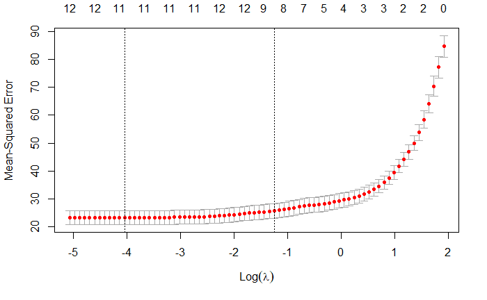

```r
cv_l1Model <- cv.glmnet(x = as.matrix(predictors),
                        y = dataSet$medv,
                        nfolds = 10)
plot(cv_l1Model)
```

```r
cv_l1Model$lambda
```

```
 [1] 6.777653645 6.175545575 5.626927127 5.127046430 4.671573757 4.256564020 3.878422604 3.533874230 3.219934583 2.933884470
[11] 2.673246260 2.435762430 2.219376009 2.022212762 1.842564953 1.678876561 1.529729795 1.393832816 1.270008551 1.157184491
[21] 1.054383411 0.960714894 0.875367631 0.797602383 0.726745586 0.662183511 0.603356953 0.549756384 0.500917542 0.456417409
[31] 0.415870544 0.378925751 0.345263032 0.314590816 0.286643435 0.261178822 0.237976415 0.216835246 0.197572201 0.180020431
[41] 0.164027912 0.149456124 0.136178854 0.124081100 0.113058077 0.103014309 0.093862802 0.085524289 0.077926547 0.071003768
[51] 0.064695989 0.058948575 0.053711746 0.048940143 0.044592435 0.040630966 0.037021423 0.033732542 0.030735836 0.028005349
[61] 0.025517431 0.023250533 0.021185020 0.019303001 0.017588175 0.016025690 0.014602012 0.013304810 0.012122847 0.011045887
[71] 0.010064601 0.009170489 0.008355808 0.007613501 0.006937139 0.006320863
```

The mean cross-validated error across the tried out values of $\lambda$ is:

```r
cv_l1Model$cvm
```

```
 [1] 84.64485 77.19867 70.42595 64.04553 58.47547 53.85140 50.01429 46.83039 44.17979 41.77450 39.44154 37.47906 35.85059
[14] 34.49895 33.37742 32.44686 31.67511 31.03853 30.50641 30.04296 29.64760 29.27726 28.89847 28.55098 28.26547 28.03096
[27] 27.84064 27.65532 27.40133 27.11650 26.77961 26.45077 26.17824 25.93905 25.72151 25.51628 25.33942 25.19726 25.06641
[40] 24.91258 24.73175 24.52345 24.31860 24.14642 24.00223 23.88135 23.78013 23.69518 23.62390 23.56374 23.51367 23.47127
[53] 23.43585 23.40711 23.38283 23.36281 23.34696 23.33677 23.32809 23.32351 23.31966 23.31730 23.31541 23.31427 23.31363
[66] 23.31401 23.31444 23.31571 23.31670 23.31760 23.31829 23.31904 23.31981 23.32041 23.32178 23.32314
```

And the respective value of $\lambda$ is:

```r
cv_l1Model$lambda.min
```

```
[1] 0.01758818
```

So the optimal Lasso model would be:

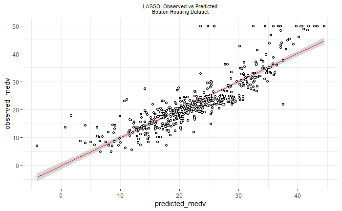

```r
l1Optim_Model <- glmnet(predictors,
                        y = dataSet$medv,
                        lambda = cv_l1Model$lambda.min)
predicted_medv <- predict(l1Optim_Model,
                          newx = as.matrix(predictors))
predictFrame <- data.frame(predicted_medv = predicted_medv,
                           observed_medv = dataSet$medv)
ggplot(data = predictFrame,
       aes(x = predicted_medv,
           y = observed_medv)) +
  geom_smooth(method = "lm", size = .25, color = "red") +
  geom_point(size = 1.5, color = "black") +
  geom_point(size = .75, color = "white") +
  ggtitle("LASSO: Observed vs Predicted\nBoston Housing Dataset") +
  theme_bw() +
  theme(panel.border = element_blank()) +
  theme(plot.title = element_text(hjust = .5, size = 8))
```

The $L2$ or Ridge regression is obtained from {glmnet} by setting `alpha` to zero:

```r
predictors <- dataSet %>%
  dplyr::select(-medv)
l2_Model <- glmnet(predictors,
                   y = dataSet$medv,
                   alpha = 0)
l2_Model$lambda
```

```
  [1] 6777.6536446 6175.5455754 5626.9271274 5127.0464303 4671.5737566 4256.5640198 3878.4226042 3533.8742298 3219.9345832
 [10] 2933.8844696 2673.2462597 2435.7624300 2219.3760091 2022.2127615 1842.5649534 1678.8765614 1529.7297950 1393.8328162
 [19] 1270.0085505 1157.1844913 1054.3834105  960.7148944  875.3676311  797.6023834  726.7455860  662.1835112  603.3569532
 [28]  549.7563844  500.9175425  456.4174086  415.8705440  378.9257511  345.2630318  314.5908156  286.6434347  261.1788220
 [37]  237.9764153  216.8352465  197.5722008  180.0204310  164.0279121  149.4561245  136.1788543  124.0811002  113.0580773
 [46]  103.0143093   93.8628020   85.5242894   77.9265472   71.0037676   64.6959885   58.9485752   53.7117463   48.9401428
 [55]   44.5924354   40.6309663   37.0214233   33.7325421   30.7358360   28.0053490   25.5174310   23.2505328   21.1850195
 [64]   19.3030008   17.5881754   16.0256904   14.6020122   13.3048097   12.1228471   11.0458868   10.0646006    9.1704892
 [73]    8.3558082    7.6135013    6.9371388    6.3208625    5.7593345    5.2476911    4.7815007    4.3567253    3.9696859
 [82]    3.6170299    3.2957030    3.0029218    2.7361505    2.4930784    2.2716002    2.0697975    1.8859224    1.7183823
 [91]    1.5657259    1.4266311    1.2998932    1.1844142    1.0791941    0.9833215    0.8959659    0.8163708    0.7438467
[100]    0.6777654
```

Remember: The `alpha` parameter (has a default value of `1`) is the *Elastic Net mixing parameter*: the mixing parameter between Ridge ($\alpha=0$) and Lasso ($\alpha=1$).

The {glmnet} package will perform an automatic cross-validation across $\lambda$, as demonstrated, but you will need to develop your own cross-validation for the mixing parameter $\alpha$.

### 3. The Bias-Variance Tradeoff

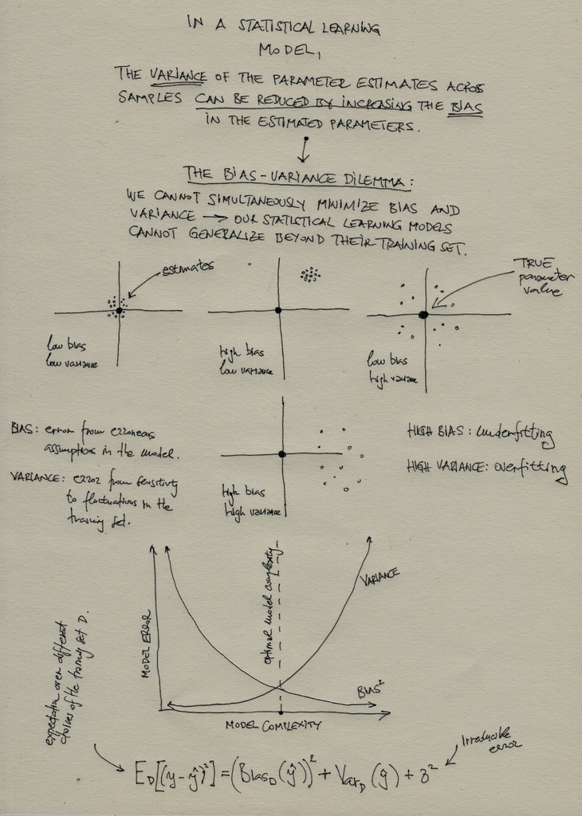

### 2. Run R code in parallel w. {snowfall}

Let’s clean up our environment first, set the `dataDir` again, and import the {snowfall} library:

```r
rm(list = ls())
dataDir <- paste0(getwd(), "/_data/")
library(snowfall)
library(randomForest)
```

We choose to parallelize R code with {snowfall} because it presents arguably the simplest interface for parallel computation R.

We are getting back to the `HR_comma_sep.csv` dataset and the Random Forest model:

```r
dataSet <- read.csv(paste0(getwd(), "/_data/HR_comma_sep.csv"),
                    header = T,
                    check.names = 1,
                    stringsAsFactors = F)
glimpse(dataSet)
```

```
Rows: 14,999
Columns: 10
$ satisfaction_level    <dbl> 0.38, 0.80, 0.11, 0.72, 0.37, 0.41, 0.10, 0.92, 0.89, 0.42, 0.45, 0.11, 0.84, 0.41, 0.36, 0.38...
$ last_evaluation       <dbl> 0.53, 0.86, 0.88, 0.87, 0.52, 0.50, 0.77, 0.85, 1.00, 0.53, 0.54, 0.81, 0.92, 0.55, 0.56, 0.54...
$ number_project        <int> 2, 5, 7, 5, 2, 2, 6, 5, 5, 2, 2, 6, 4, 2, 2, 2, 2, 4, 2, 5, 6, 2, 6, 2, 2, 5, 4, 2, 2, 2, 6, 2...
$ average_montly_hours  <int> 157, 262, 272, 223, 159, 153, 247, 259, 224, 142, 135, 305, 234, 148, 137, 143, 160, 255, 160,...
$ time_spend_company    <int> 3, 6, 4, 5, 3, 3, 4, 5, 5, 3, 3, 4, 5, 3, 3, 3, 3, 6, 3, 5, 4, 3, 4, 3, 3, 5, 5, 3, 3, 3, 4, 3...
$ Work_accident         <int> 0, 0, 0, 0, 0, 0, 0, 0, 0, 0, 0, 0, 0, 0, 0, 0, 0, 0, 1, 0, 0, 0, 0, 0, 0, 0, 0, 0, 0, 0, 0, 0...
$ left                  <int> 1, 1, 1, 1, 1, 1, 1, 1, 1, 1, 1, 1, 1, 1, 1, 1, 1, 1, 1, 1, 1, 1, 1, 1, 1, 1, 1, 1, 1, 1, 1, 1...
$ promotion_last_5years <int> 0, 0, 0, 0, 0, 0, 0, 0, 0, 0, 0, 0, 0, 0, 0, 0, 0, 0, 1, 0, 0, 0, 0, 0, 0, 0, 0, 0, 0, 0, 0, 0...
$ sales                 <chr> "sales", "sales", "sales", "sales", "sales", "sales", "sales", "sales", "sales", "sales", "sal...
$ salary                <chr> "low", "medium", "medium", "low", "low", "low", "low", "low", "low", "low", "low", "low", "low...
```

We will immediately add the `ix` column to the dataset to prepare it for a 5-fold cross-validation:

```r
dataSet$ix <- sample(1:5, dim(dataSet)[1], replace = T)
table(dataSet$ix)
```

```
   1    2    3    4    5
3081 2957 3000 2992 2969
```

Recall that in our previous Session 21 it took approximately 17 minutes to cross-validate a set of Random Forest models for this dataset with the following ranges of parameters `ntree` and `mtry` in a 5-fold CV:

```r
ntree <- seq(250, 1000, by = 250)
mtry <- 1:(dim(dataSet)[2]-2)
folds <- 1:5
```

Now we want to make the CV procedure way more efficient by growing many Random Forest models in parallel. This is how we approach the problem in a typical {snowfall} workflow:

```r
cv_design <- expand.grid(ntree, mtry, folds)
colnames(cv_design) <- c('ntree', 'mtry', 'fold')
head(cv_design)
```

|  | ntree | mtry | fold |
| --- | --- | --- | --- |
| 1 | 250 | 1 | 1 |
| 2 | 500 | 1 | 1 |
| 3 | 750 | 1 | 1 |
| 4 | 1000 | 1 | 1 |
| 5 | 250 | 2 | 1 |
| 6 | 500 | 2 | 1 |

The `expand.grid()` function is used to combine several factors in order of fast they change in a design matrix. This time it helped us planned our CV procedure by efficiently combining all levels of `ntree`, `mtry`, and `fold`. Each of the 180 rows in the `cv_design` data.frame describes exactly one Random Forest model that we need to grow, each model described by a particular value of `ntree`, `mtry` and the `fold` that will be used as a test dataset. Now we want to *turn `cv_design` into a list*:

```r
cv_design <- apply(cv_design, 1, function(x) {
  list(ntree = x[1],
       mtry = x[2],
       fold = x[3])
})
```

Now we can do things such as:

```r
cv_design[[1]]
```

```
$ntree
ntree
  250

$mtry
mtry
   1

$fold
fold
   1
```

and:

```r
cv_design[[1]]$ntree
```

```
ntree
  250
```

In {snowfall}, we use a special family of parallelized `*apply()` functions. But before we demonstrate that, we need a bit of a preparation. We will now turn your computer into a cluster (!). All modern CPUs have mulitple threads that can be used as separate logical units for computation. In this approach, we will make each thread available on your system work on a separate Random Forest model in parallel, thus speeding up the CV procedure.

The package `{parallel}` is present by default in your R installation. Call `parallel::detectCores()` to detect the number of threads that you can use:

```r
parallel::detectCores()
```

```
[1] 8
```

Pronounce `parallel::detectCores() - 1` to be a numeric `numCores`:

```r
numCores <- parallel::detectCores() - 1
numCores
```

```
[1] 7
```

Now we need to initialize a cluster with `numCores` workers:

```r
sfInit(parallel = TRUE, cpus = numCores)
```

```
R Version:  R version 4.0.0 (2020-04-24)
```

Next, we need to export the data *and the functions* that we will use to the cluster:

```r
sfExport('dataSet')
sfLibrary(dplyr)
```

```
Library dplyr loaded.
```

```r
sfLibrary(randomForest)
```

```
Library randomForest loaded.
```

Finally, we need to code our CV procedure to run in parallel. Here is how we can do that:

```r
tstart <- Sys.time()
rfModels <- sfClusterApplyLB(cv_design, function(x) {
  # - pick up parameters from x
  ntree <- x$ntree
  mtry <- x$mtry
  fold <- x$fold
  # - split training and test sets
  testIx <- fold
  trainIx <- setdiff(1:5, testIx)
  trainSet <- dataSet %>%
    dplyr::filter(ix %in% trainIx) %>%
    dplyr::select(-ix)
  testSet <- dataSet %>%
    dplyr::filter(ix %in% testIx) %>%
    dplyr::select(-ix)
  # - `left` to factor for classification w. randomForest()
  trainSet$left <- as.factor(trainSet$left)
  testSet$left <- as.factor(testSet$left)
  # - Random Forest:
  model <- randomForest::randomForest(formula = left ~ .,
                                      data = trainSet,
                                      ntree = ntree,
                                      mtry = mtry
                                      )
  # - ROC analysis:
  predictions <- predict(model,
                         newdata = testSet)
  hit <- sum(ifelse(predictions == 1 & testSet$left == 1, 1, 0))
  hit <- hit/sum(testSet$left == 1)
  fa <- sum(ifelse(predictions == 1 & testSet$left == 0, 1, 0))
  fa <- fa/sum(testSet$left == 0)
  acc <- sum(predictions == testSet$left)
  acc <- acc/length(testSet$left)
  # - Output:
  return(
    data.frame(ntree = ntree,
               mtry = mtry,
               fold = fold,
               hit = hit,
               fa = fa,
               acc = acc)
  )
})
# - collect all results
rfModels <- rbindlist(rfModels)
write.csv(rfModels,
          paste0(getwd(), "/rfModels.csv"))
# - Report timing:
print(paste0("The estimation took: ",
             difftime(Sys.time(), tstart, units = "mins"),
             " minutes."))
```

```
[1] "The estimation took: 9.98846626679103 minutes."
```

**Do not forget to shutdown the cluster:**

```r
sfStop()
```

And here are the average results across the values of `ntree` and `mtry`:

```r
rfModels <- rfModels %>%
  group_by(ntree, mtry) %>%
  summarise(hit = mean(hit),
            fa = mean(fa),
            acc = mean(acc))
rfModels
```

| ntree | mtry | hit | fa | acc |
| --- | --- | --- | --- | --- |
| 250 | 1 | 0.7732493 | 0.002638333 | 0.9440707 |
| 250 | 2 | 0.9576694 | 0.002188665 | 0.9882711 |
| 250 | 3 | 0.9740155 | 0.001828586 | 0.9924172 |
| 250 | 4 | 0.9742690 | 0.001650702 | 0.9926165 |
| 250 | 5 | 0.9745572 | 0.001917410 | 0.9924798 |
| 250 | 6 | 0.9745572 | 0.002180301 | 0.9922784 |
| 250 | 7 | 0.9742751 | 0.002525182 | 0.9919486 |
| 250 | 8 | 0.9742888 | 0.002614059 | 0.9918801 |
| 250 | 9 | 0.9742888 | 0.003582580 | 0.9911416 |
| 500 | 1 | 0.7939965 | 0.002720471 | 0.9489010 |

[output cut: 26 more lines]

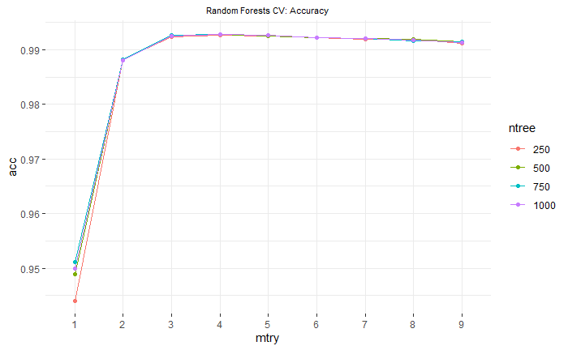

```r
rfModels$ntree <- factor(rfModels$ntree)
rfModels$mtry <- factor(rfModels$mtry)
ggplot(data = rfModels,
       aes(x = mtry,
           y = acc,
           group = ntree,
           color = ntree,
           fill = ntree,
           label = round(acc, 2))
       ) +
  geom_path(size = .25) +
  geom_point(size = 1.5) +
  ggtitle("Random Forests CV: Accuracy") +
  theme_bw() +
  theme(panel.border = element_blank()) +
  theme(plot.title = element_text(hjust = .5, size = 8))
```

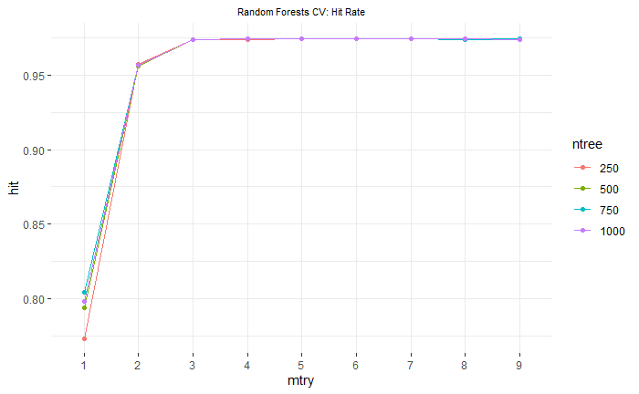

```r
ggplot(data = rfModels,
       aes(x = mtry,
           y = hit,
           group = ntree,
           color = ntree,
           fill = ntree,
           label = round(acc, 2))
       ) +
  geom_path(size = .25) +
  geom_point(size = 1.5) +
  ggtitle("Random Forests CV: Hit Rate") +
  theme_bw() +
  theme(panel.border = element_blank()) +
  theme(plot.title = element_text(hjust = .5, size = 8))
```

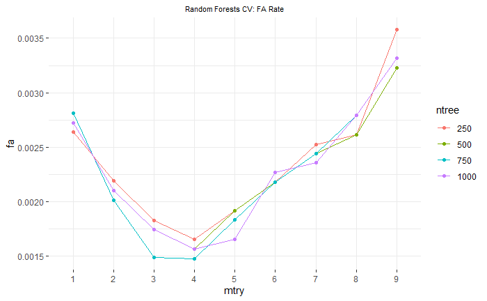

```r
ggplot(data = rfModels,
       aes(x = mtry,
           y = fa,
           group = ntree,
           color = ntree,
           fill = ntree,
           label = round(acc, 2))
       ) +
  geom_path(size = .25) +
  geom_point(size = 1.5) +
  ggtitle("Random Forests CV: FA Rate") +
  theme_bw() +
  theme(panel.border = element_blank()) +
  theme(plot.title = element_text(hjust = .5, size = 8))
```

### Further Readings

- [L1 and L2 Regularization Methods, Anuja Nagpal, Towards Data Science](https://towardsdatascience.com/l1-and-l2-regularization-methods-ce25e7fc831c)
- [L2 and L1 Regularization in Machine Learning, Neelam Tyagi, analyticsteps](https://www.analyticssteps.com/blogs/l2-and-l1-regularization-machine-learning)
- [An Introduction to glmnet, Trevor Hastie, Junyang Qian, Kenneth Tay, February 22, 2021](https://glmnet.stanford.edu/articles/glmnet.html)
- [Bias–variance tradeoff, English Wikipedia](https://en.wikipedia.org/wiki/Bias%E2%80%93variance_tradeoff)
- [Developing parallel programs using snowfall, Jochen Knaus, 2010-03-04](https://cran.r-project.org/web/packages/snowfall/vignettes/snowfall.pdf)

Goran S. Milovanović

DataKolektiv, 2020/21

contact: goran.milovanovic@datakolektiv.com

License: [GPLv3](http://www.gnu.org/licenses/gpl-3.0.txt) This Notebook is free software: you can redistribute it and/or modify it under the terms of the GNU General Public License as published by the Free Software Foundation, either version 3 of the License, or (at your option) any later version. This Notebook is distributed in the hope that it will be useful, but WITHOUT ANY WARRANTY; without even the implied warranty of MERCHANTABILITY or FITNESS FOR A PARTICULAR PURPOSE. See the GNU General Public License for more details. You should have received a copy of the GNU General Public License along with this Notebook. If not, see http://www.gnu.org/licenses/.